# Untitled6-Copy1

```python
import numpy as np
import pandas as pd
from sklearn.model_selection import train_test_split
from sklearn.neighbors import KNeighborsClassifier
from scipy.stats import zscore
import seaborn as sns
import matplotlib.pyplot as plt
```

1. Data Understanding:

a. Read all the 3 CSV files as DataFrame and store them into 3 separate variables.

```python
#a
a= pd.read_csv('/Users/abelabykuriakose/Downloads/Normal.csv')
b= pd.read_csv('/Users/abelabykuriakose/Downloads/Type_S.csv')
c= pd.read_csv('/Users/abelabykuriakose/Downloads/Type_H.csv')
```

b.Print Shape and columns of all the 3 DataFrames.

```python
# the columns names and shape
print(a.columns)
print(a.shape)
```

```
Index(['P_incidence', 'P_tilt', 'L_angle', 'S_slope', 'P_radius', 'S_Degree',
       'Class'],
      dtype='object')
(100, 7)
```

```python
print(b.columns)
print(b.shape)
```

```
Index(['P_incidence', 'P_tilt', 'L_angle', 'S_slope', 'P_radius', 'S_Degree',
       'Class'],
      dtype='object')
(150, 7)
```

```python
print(c.columns)
print(c.shape)
```

```
Index(['P_incidence', 'P_tilt', 'L_angle', 'S_slope', 'P_radius', 'S_Degree',
       'Class'],
      dtype='object')
(60, 7)
```

d. Print DataTypes of all the 3 DataFrames.

```python
print(a.dtypes)
```

```
P_incidence    float64
P_tilt         float64
L_angle        float64
S_slope        float64
P_radius       float64
S_Degree       float64
Class           object
dtype: object
```

```python
print(b.dtypes)
```

```
P_incidence    float64
P_tilt         float64
L_angle        float64
S_slope        float64
P_radius       float64
S_Degree       float64
Class           object
dtype: object
```

```python
print(c.dtypes)
```

```
P_incidence    float64
P_tilt         float64
L_angle        float64
S_slope        float64
P_radius       float64
S_Degree       float64
Class           object
dtype: object
```

C. Compare Column names of all the 3 DataFrames and clearly write observations.

```python
def compare(df, df1):
    o = set(df.columns)
    c = set(df1.columns)

    if (c == o):
        return ('identical columns name')
    elif c.issubset(o):
        return ('missing columns in dataframe')
    elif orig.issubset(c):
        return ('extra columns in dataframe')
    else:
        return ('columns names are incorrect')

print(compare(a, b))
print(compare(b,c))
```

```
identical columns name
identical columns name
```

The columns are identical and in equal number as well.

E. Observe and share variation in ‘Class’ feature of all the 3 DaraFrames.

```python
c['Class'].value_counts()
```

```
Type_H    37
type_h    23
Name: Class, dtype: int64
```

```python
a['Class'].value_counts()
```

```
Normal    73
Nrmal     27
Name: Class, dtype: int64
```

```python
b['Class'].value_counts()
```

```
Type_S    133
tp_s       17
Name: Class, dtype: int64
```

1. Data Preparation and Exploration:

   a. Unify all the variations in ‘Class’ feature for all the 3 DataFrames.

```python
c['Class'] = c['Class'].replace(to_replace ="type_h",
                 value ="Type_H")
```

```python
c['Class'].value_counts()
```

```
Type_H    60
Name: Class, dtype: int64
```

```python
b['Class'] = b['Class'].replace(to_replace ="tp_s",
                 value ="Type_S")
```

```python
b['Class'].value_counts()
```

```
Type_S    150
Name: Class, dtype: int64
```

```python
a['Class'] = a['Class'].replace(to_replace ="Nrmal",
                 value ="Normal")
a['Class'].value_counts()
```

```
Normal    100
Name: Class, dtype: int64
```

B. Combine all the 3 DataFrames to form a single DataFrame

```python
df=pd.concat([a,b,c],axis=0,sort=False)
```

```python
df.shape
```

```
(310, 7)
```

```python
df.groupby(["Class"]).count()
```

| Class | P_incidence | P_tilt | L_angle | S_slope | P_radius | S_Degree |
| --- | --- | --- | --- | --- | --- | --- |
| Normal | 100 | 100 | 100 | 100 | 100 | 100 |
| Type_H | 60 | 60 | 60 | 60 | 60 | 60 |
| Type_S | 150 | 150 | 150 | 150 | 150 | 150 |

C.Print 5 random samples of this DataFrame

```python
#C.Print 5 random samples of this DataFrame
print(df.sample(n=5))
```

```
    P_incidence     P_tilt    L_angle    S_slope    P_radius   S_Degree  \
17    31.276012   3.144669  32.562996  28.131342  129.011418   3.623020
62    39.358705   7.011262  37.000000  32.347443  117.818760   1.904048
28    56.605771  16.800200  42.000000  39.805571  127.294522  24.018575
64    43.191915   9.976664  28.938149  33.215251  123.467400   1.741018
61    83.879941  23.077427  87.141512  60.802514  124.646072  80.555605

     Class
17  Type_H
62  Normal
28  Type_S
64  Normal
61  Type_S
```

```python
#d. Print Feature-wise percentage of Null values

percentnull = df.isnull().sum() * 100 / len(df)
print(percentnull)
```

```
P_incidence    0.0
P_tilt         0.0
L_angle        0.0
S_slope        0.0
P_radius       0.0
S_Degree       0.0
Class          0.0
dtype: float64
```

```python
#e. Check 5-point summary of the new DataFrame.- full summary of the data mentioned below

df.describe().transpose()
```

|  | count | mean | std | min | 25% | 50% | 75% | max |
| --- | --- | --- | --- | --- | --- | --- | --- | --- |
| P_incidence | 310.0 | 60.496653 | 17.236520 | 26.147921 | 46.430294 | 58.691038 | 72.877696 | 129.834041 |
| P_tilt | 310.0 | 17.542822 | 10.008330 | -6.554948 | 10.667069 | 16.357689 | 22.120395 | 49.431864 |
| L_angle | 310.0 | 51.930930 | 18.554064 | 14.000000 | 37.000000 | 49.562398 | 63.000000 | 125.742385 |
| S_slope | 310.0 | 42.953831 | 13.423102 | 13.366931 | 33.347122 | 42.404912 | 52.695888 | 121.429566 |
| P_radius | 310.0 | 117.920655 | 13.317377 | 70.082575 | 110.709196 | 118.268178 | 125.467674 | 163.071041 |
| S_Degree | 310.0 | 26.296694 | 37.559027 | -11.058179 | 1.603727 | 11.767934 | 41.287352 | 418.543082 |

```python
from numpy import percentile
df.quantile(q=0.25, axis=0)
```

```
P_incidence     46.430294
P_tilt          10.667069
L_angle         37.000000
S_slope         33.347122
P_radius       110.709196
S_Degree         1.603727
Name: 0.25, dtype: float64
```

```python
df.quantile(q=0.5, axis=0)
```

```
P_incidence     58.691038
P_tilt          16.357689
L_angle         49.562398
S_slope         42.404912
P_radius       118.268178
S_Degree        11.767934
Name: 0.5, dtype: float64
```

```python
df.quantile(q=0.75, axis=0)
```

```
P_incidence     72.877696
P_tilt          22.120395
L_angle         63.000000
S_slope         52.695888
P_radius       125.467674
S_Degree        41.287352
Name: 0.75, dtype: float64
```

```python
df.min()
```

```
P_incidence    26.147921
P_tilt         -6.554948
L_angle             14.0
S_slope        13.366931
P_radius       70.082575
S_Degree      -11.058179
Class             Normal
dtype: object
```

```python
df.max()
```

```
P_incidence    129.834041
P_tilt          49.431864
L_angle        125.742385
S_slope        121.429566
P_radius       163.071041
S_Degree       418.543082
Class              Type_S
dtype: object
```

PART 3

```
             P_incidence    P_tilt   L_angle   S_slope  P_radius  S_Degree
P_incidence     1.000000  0.629199  0.717282  0.814960 -0.247467  0.638743
P_tilt          0.629199  1.000000  0.432764  0.062345  0.032668  0.397862
L_angle         0.717282  0.432764  1.000000  0.598387 -0.080344  0.533667
S_slope         0.814960  0.062345  0.598387  1.000000 -0.342128  0.523557
P_radius       -0.247467  0.032668 -0.080344 -0.342128  1.000000 -0.026065
S_Degree        0.638743  0.397862  0.533667  0.523557 -0.026065  1.000000
```

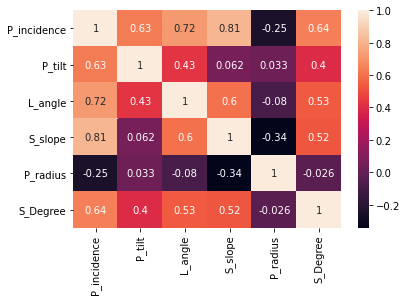

```python
#a. Visualize a heatmap to understand correlation between all features
#b. Share insights on correlation.
#i. Features having stronger correlation with correlation value.
#ii. Features having weaker correlation with correlation value.


print(df.corr())

dp = sns.heatmap(df.corr(),annot=True)
```

Features having stronger correlation with correlation value(positive values):

1.P_tilt,P_incidence=0.63

2.P_incidence,L_angle=0.72

3.P_incidence,S_slope=0.81

Features having weaker correlation with correlation value(negative values):

2.S_slope,P_radius=-0.34

3.S_Degree,P_radius=-0.026

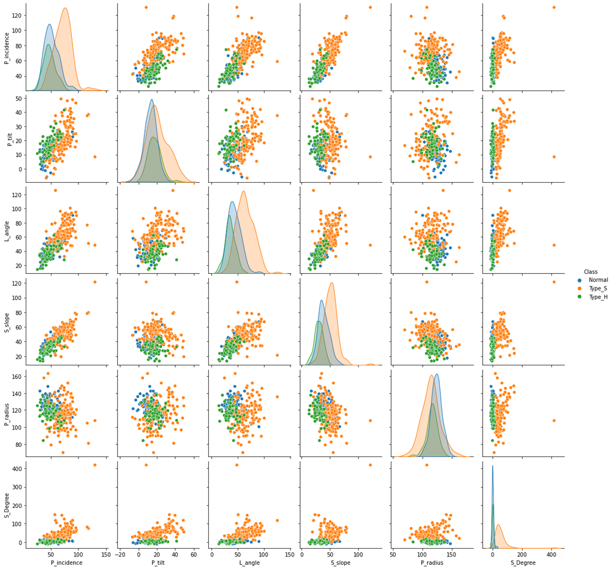

```python
# Visualize a pairplot with 3 classes distinguished by colors and share insights.

sns.pairplot(df,hue = 'Class')
```

1.P_incidence, P_tilt follows ,L_angle,and S_slope follows follows a linear relation (increasing trend) with Type_S dominating. THe higher values are of the features reflect type_S and mostly Type_H for lower values. 2.for higher S_Degree- more Type_S classes 3.For less values of P_incidence and P_tilt- there are normal classes

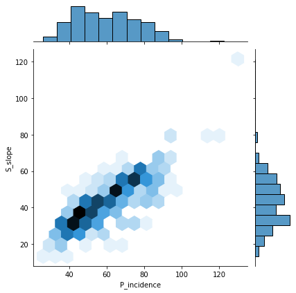

```python
#d. Visualize a jointplot for ‘P_incidence’ and ‘S_slope’ and share insights.
sns.jointplot(x = "P_incidence", y = "S_slope",
              kind = "hex", data = df)
```

1.S_slope and P_incidence has high Correlation and max value between 40-60(p-incidence) and 20-40(S_slope).They have an almost similar distribution.

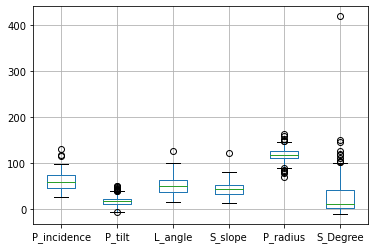

```python
#e. Visualize a boxplot to check distribution of the features and share insights.

df.boxplot(column =['P_incidence','P_tilt','L_angle','S_slope','P_radius','S_Degree'])
```

PART 4

```python
df.dtypes
```

```
P_incidence    float64
P_tilt         float64
L_angle        float64
S_slope        float64
P_radius       float64
S_Degree       float64
Class           object
dtype: object
```

```python
#a. Split data into X and Y.

X = df.drop(labels= "Class" , axis = 1)
y = df["Class"]
```

```python
# convert the features into z scores as we do not know what units

XScaled  = X.apply(zscore)  # convert all attributes to Z scale

XScaled.describe()
```

|  | P_incidence | P_tilt | L_angle | S_slope | P_radius | S_Degree |
| --- | --- | --- | --- | --- | --- | --- |
| count | 3.100000e+02 | 3.100000e+02 | 3.100000e+02 | 3.100000e+02 | 3.100000e+02 | 3.100000e+02 |
| mean | -8.559461e-17 | 2.222237e-16 | 3.137275e-16 | -1.493429e-16 | -5.624533e-16 | -5.228792e-17 |
| std | 1.001617e+00 | 1.001617e+00 | 1.001617e+00 | 1.001617e+00 | 1.001617e+00 | 1.001617e+00 |
| min | -1.996010e+00 | -2.411664e+00 | -2.047652e+00 | -2.207741e+00 | -3.597963e+00 | -9.961725e-01 |
| 25% | -8.173982e-01 | -6.881138e-01 | -8.060267e-01 | -7.168418e-01 | -5.423830e-01 | -6.585073e-01 |
| 50% | -1.049246e-01 | -1.186061e-01 | -1.278621e-01 | -4.095971e-02 | 2.613767e-02 | -3.874502e-01 |
| 75% | 7.194643e-01 | 4.581158e-01 | 5.975493e-01 | 7.269414e-01 | 5.676209e-01 | 3.997679e-01 |
| max | 4.029206e+00 | 3.191402e+00 | 3.984615e+00 | 5.855771e+00 | 3.395818e+00 | 1.046035e+01 |

```python
# Split X and y into training and test set in 80:20 ratio

X_train, X_test, y_train, y_test = train_test_split(XScaled, y, test_size=0.20, random_state=1)
```

```python
from sklearn.preprocessing import StandardScaler
sc = StandardScaler()
X_train = sc.fit_transform(X_train)
X_test = sc.transform(X_test)
```

```python
NNH = KNeighborsClassifier(n_neighbors= 3 , weights = 'distance' )
```

```python
NNH.fit(X_train, y_train)
```

```
KNeighborsClassifier(n_neighbors=3, weights='distance')
```

```python
y_pred = NNH.predict(X_test)
```

```python
from sklearn.metrics import accuracy_score
accuracy_score(y_test,y_pred)
```

```
0.7419354838709677
```

```python
from sklearn.metrics import classification_report, confusion_matrix
print(classification_report(y_test,y_pred))
```

```
              precision    recall  f1-score   support

      Normal       0.57      0.67      0.62        18
      Type_H       0.78      0.58      0.67        12
      Type_S       0.84      0.84      0.84        32

    accuracy                           0.74        62
   macro avg       0.73      0.70      0.71        62
weighted avg       0.75      0.74      0.74        62
```

Part 5

```python
#a. Tune the parameters:


scores =[]
for k in range(1,50):
    NNH = KNeighborsClassifier(n_neighbors = k, weights = 'distance' )
    NNH.fit(X_train, y_train)
    scores.append(NNH.score(X_test, y_test))
```

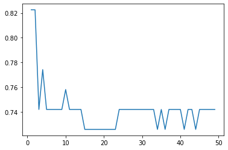

```python
plt.plot(range(1,50),scores)
```

```python
myList = list(range(1,50))


neighbors = list(filter(lambda x: x % 2 != 0, myList))

ac_scores = []

for k in neighbors:
    knn = KNeighborsClassifier(n_neighbors=k)
    knn.fit(X_train, y_train)
    # predict the response
    y_pred = knn.predict(X_test)
    # evaluate accuracy
    scores = accuracy_score(y_test, y_pred)
    ac_scores.append(scores)

MSE = [1 - x for x in ac_scores]

# determining best k
optimal_k = neighbors[MSE.index(min(MSE))]
print("The optimal number of neighbors is %d" % optimal_k)
```

```
The optimal number of neighbors is 1
```

```python
#Using k=1 as the final model for prediction
knn = KNeighborsClassifier(n_neighbors = 1)


knn.fit(X_train, y_train)


y_pred = knn.predict(X_test)

print(accuracy_score(y_test, y_pred))
```

```
0.8225806451612904
```

```python
print(classification_report(y_test,y_pred))
```

```
              precision    recall  f1-score   support

      Normal       0.70      0.78      0.74        18
      Type_H       0.83      0.83      0.83        12
      Type_S       0.90      0.84      0.87        32

    accuracy                           0.82        62
   macro avg       0.81      0.82      0.81        62
weighted avg       0.83      0.82      0.82        62
```

5b. Clearly showcase improvement in performance achieved

There is a close 8% increase in Accuracy, 8% increase in Precision, 8% increase in recall, 8% increase in f1-score .

5c.Clearly state which parameters contributed most to improve model performance. What could be the probable reason?

K value contributred to the same.

PART 2

```python
#1.a

e= pd.read_csv('/Users/abelabykuriakose/Downloads/Data1.csv')
f= pd.read_csv('/Users/abelabykuriakose/Downloads/Data2.csv')
```

```python
#1.b

print(e.shape)
print(e.columns)
print(e.dtypes)
```

```
(5000, 8)
Index(['ID', 'Age', 'CustomerSince', 'HighestSpend', 'ZipCode', 'HiddenScore',
       'MonthlyAverageSpend', 'Level'],
      dtype='object')
ID                       int64
Age                      int64
CustomerSince            int64
HighestSpend             int64
ZipCode                  int64
HiddenScore              int64
MonthlyAverageSpend    float64
Level                    int64
dtype: object
```

```python
print(f.shape)
print(f.columns)
print(f.dtypes)
```

```
(5000, 7)
Index(['ID', 'Mortgage', 'Security', 'FixedDepositAccount', 'InternetBanking',
       'CreditCard', 'LoanOnCard'],
      dtype='object')
ID                       int64
Mortgage                 int64
Security                 int64
FixedDepositAccount      int64
InternetBanking          int64
CreditCard               int64
LoanOnCard             float64
dtype: object
```

```python
f
```

|  | ID | Mortgage | Security | FixedDepositAccount | InternetBanking | CreditCard | LoanOnCard |
| --- | --- | --- | --- | --- | --- | --- | --- |
| 0 | 1 | 0 | 1 | 0 | 0 | 0 | NaN |
| 1 | 2 | 0 | 1 | 0 | 0 | 0 | NaN |
| 2 | 3 | 0 | 0 | 0 | 0 | 0 | NaN |
| 3 | 4 | 0 | 0 | 0 | 0 | 0 | NaN |
| 4 | 5 | 0 | 0 | 0 | 0 | 1 | NaN |
| ... | ... | ... | ... | ... | ... | ... | ... |
| 4995 | 4996 | 0 | 0 | 0 | 1 | 0 | 0.0 |
| 4996 | 4997 | 85 | 0 | 0 | 1 | 0 | 0.0 |
| 4997 | 4998 | 0 | 0 | 0 | 0 | 0 | 0.0 |
| 4998 | 4999 | 0 | 0 | 0 | 1 | 0 | 0.0 |
| 4999 | 5000 | 0 | 0 | 0 | 1 | 1 | 0.0 |

5000 rows × 7 columns

```python
#1.c.

df2=pd.merge(e,f,how='outer',on='ID')
```

```python
df2
```

|  | ID | Age | CustomerSince | HighestSpend | ZipCode | HiddenScore | MonthlyAverageSpend | Level | Mortgage | Security | FixedDepositAccount | InternetBanking | CreditCard | LoanOnCard |
| --- | --- | --- | --- | --- | --- | --- | --- | --- | --- | --- | --- | --- | --- | --- |
| 0 | 1 | 25 | 1 | 49 | 91107 | 4 | 1.6 | 1 | 0 | 1 | 0 | 0 | 0 | NaN |
| 1 | 2 | 45 | 19 | 34 | 90089 | 3 | 1.5 | 1 | 0 | 1 | 0 | 0 | 0 | NaN |
| 2 | 3 | 39 | 15 | 11 | 94720 | 1 | 1.0 | 1 | 0 | 0 | 0 | 0 | 0 | NaN |
| 3 | 4 | 35 | 9 | 100 | 94112 | 1 | 2.7 | 2 | 0 | 0 | 0 | 0 | 0 | NaN |
| 4 | 5 | 35 | 8 | 45 | 91330 | 4 | 1.0 | 2 | 0 | 0 | 0 | 0 | 1 | NaN |
| ... | ... | ... | ... | ... | ... | ... | ... | ... | ... | ... | ... | ... | ... | ... |
| 4995 | 4996 | 29 | 3 | 40 | 92697 | 1 | 1.9 | 3 | 0 | 0 | 0 | 1 | 0 | 0.0 |
| 4996 | 4997 | 30 | 4 | 15 | 92037 | 4 | 0.4 | 1 | 85 | 0 | 0 | 1 | 0 | 0.0 |
| 4997 | 4998 | 63 | 39 | 24 | 93023 | 2 | 0.3 | 3 | 0 | 0 | 0 | 0 | 0 | 0.0 |
| 4998 | 4999 | 65 | 40 | 49 | 90034 | 3 | 0.5 | 2 | 0 | 0 | 0 | 1 | 0 | 0.0 |
| 4999 | 5000 | 28 | 4 | 83 | 92612 | 3 | 0.8 | 1 | 0 | 0 | 0 | 1 | 1 | 0.0 |

5000 rows × 14 columns

```python
df2.dtypes
```

```
ID                       int64
Age                      int64
CustomerSince            int64
HighestSpend             int64
ZipCode                  int64
HiddenScore              int64
MonthlyAverageSpend    float64
Level                    int64
Mortgage                 int64
Security                 int64
FixedDepositAccount      int64
InternetBanking          int64
CreditCard               int64
LoanOnCard             float64
dtype: object
```

```python
#1.d

df2['CreditCard']=df2['CreditCard'].astype(str)
df2['InternetBanking']=df2['InternetBanking'].astype(str)
df2['FixedDepositAccount']=df2['FixedDepositAccount'].astype(str)
df2['Security']=df2['Security'].astype(str)
df2['Level']=df2['Level'].astype(str)
df2['HiddenScore']=df2['HiddenScore'].astype(str)
```

```python
df2.dtypes
```

```
ID                       int64
Age                      int64
CustomerSince            int64
HighestSpend             int64
ZipCode                  int64
HiddenScore             object
MonthlyAverageSpend    float64
Level                   object
Mortgage                 int64
Security                object
FixedDepositAccount     object
InternetBanking         object
CreditCard              object
LoanOnCard             float64
dtype: object
```

1. Data Exploration and Analysis:

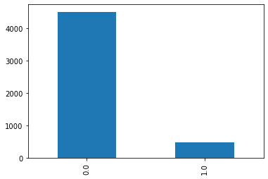

```python
#2a. Visualize distribution of Target variable ‘LoanOnCard’ and clearly share insights.

df2['LoanOnCard'].value_counts().plot(kind='bar')
```

```python
#b. Check the percentage of missing values and impute if required.

percentnull = df2.isnull().sum() * 100 / len(df2)
print(percentnull)
```

```
ID                     0.0
Age                    0.0
CustomerSince          0.0
HighestSpend           0.0
ZipCode                0.0
HiddenScore            0.0
MonthlyAverageSpend    0.0
Level                  0.0
Mortgage               0.0
Security               0.0
FixedDepositAccount    0.0
InternetBanking        0.0
CreditCard             0.0
LoanOnCard             0.4
dtype: float64
```

```python
df2.dropna(inplace=True)  # Droping the one the rows that have multiple missing values as LoanOnCard is a binary equivalent to a categorical variable(yes/no)
df2.isnull().sum()
```

```
ID                     0
Age                    0
CustomerSince          0
HighestSpend           0
ZipCode                0
HiddenScore            0
MonthlyAverageSpend    0
Level                  0
Mortgage               0
Security               0
FixedDepositAccount    0
InternetBanking        0
CreditCard             0
LoanOnCard             0
dtype: int64
```

```python
#2c. Check for unexpected values in each categorical variable and impute with best suitable value.

expected = df2['LoanOnCard'].isin([0,1]).all()
print("TRUE")

#True represent no unexpected values
```

```
TRUE
```

```python
df2=df2.drop('ID', axis=1)
df2=df2.drop('ZipCode', axis=1)
```